# Cleaning and features for RQ1: real cost per m² of new houses

Stats NZ, August 2026 release: from the raw tables to one modelling frame

Group 8 · STAT462 Assessment 1

This document turns the raw Stats NZ tables into the one table RQ1 is modelled on: one row per district and quarter, a response (log of real dollars per square metre of new houses) and a set of features. It follows the decisions the EDA ended with. The next document (`03_modelling.Rmd`) only reads the file this one saves.

# 1 Settings

Two choices live here so they are easy to change and easy to see.

```r
# smallest number of new houses in a district-quarter for its $/m² to be trusted.
# The EDA showed the extreme values come from quarters with 5-6 houses.
min_houses <- 10

# train on quarters up to and including this year, test on everything after
train_end_year <- 2019
```

The split is time-ordered because districts move together within a year, so a random split would leak the national cycle into the test set.

# 2 Set up

```r
stopifnot("data_root does not exist: set STAT462_DATA or edit the fallback in the setup chunk" = dir.exists(data_root))

# cleaned data goes next to the raw folder, outside the repo
derived_dir <- file.path(dirname(normalizePath(data_root)), "derived")
dir.create(derived_dir, showWarnings = FALSE)

f_ta         <- "Building consents by territorial authority (Monthly).csv"
f_region_q   <- "Building consents by region (Quarterly).csv"
f_per1000_ta <- "New dwellings consented per 1000 residents by territorial authority (Annual).csv"
f_sa2_2026   <- "New dwellings consented by 2026 statistical area 2 (Monthly).csv"

needed <- c(f_ta, f_region_q, f_per1000_ta, f_sa2_2026)
missing_files <- needed[!file.exists(file.path(data_root, needed))]
if (length(missing_files) > 0) stop("Missing from data_root: ", paste(missing_files, collapse = "; "))
```

The reader is the same as in the EDA: `Period` stays text, because read as a number October (`2025.10`) becomes `2025.1`.

```r
infoshare_cols <- cols(
  Series_reference = col_character(),
  Period           = col_character(),
  Data_value       = col_double(),
  Suppressed       = col_character(),
  Status           = col_character(),
  Units            = col_character(),
  Magnitude        = col_integer(),
  Subject          = col_character(),
  Group            = col_character(),
  Series_title_1   = col_character(),
  Series_title_2   = col_character(),
  Series_title_3   = col_character(),
  Series_title_4   = col_character(),
  Series_title_5   = col_character()
)

read_infoshare <- function(file) {
  read_csv(file.path(data_root, file), col_types = infoshare_cols,
           na = c("", "NA"), progress = FALSE)
}

# "YYYY.MM" -> year and calendar quarter of that month
period_year    <- function(p) as.integer(substr(p, 1, 4))
period_quarter <- function(p) (as.integer(substr(p, 6, 7)) - 1L) %/% 3L + 1L
```

# 3 The district-quarter frame

## 3.1 Load the territorial authority file

Only new work is needed, and only seven building types. They are all at different levels of the hierarchy, so each is used on its own and never summed with another: `Houses` for the response, `Dwelling units` and the three multi-unit types for the type mix, and `Non-residential buildings` and `All buildings` for the non-residential share. The load is cached because the file is large.

```r
type_short <- c("Houses"                                        = "houses",
                "Dwelling units"                                = "dwellings",
                "Apartments"                                    = "apartments",
                "Retirement village units"                      = "retirement",
                "Townhouses, flats, units, and other dwellings" = "townhouses",
                "Non-residential buildings"                     = "nonres",
                "All buildings"                                 = "allbld")
measure_short <- c("Number" = "n", "Value" = "value", "Floor area" = "area")

df_ta <- read_infoshare(f_ta) %>%
  filter(Series_title_3 == "New",
         Series_title_1 != "New Zealand",
         Series_title_2 %in% names(type_short)) %>%
  transmute(area          = Series_title_1,
            building_type = Series_title_2,
            measure       = Series_title_4,
            Period,
            Data_value)

dim(df_ta)
```

```
## [1] 624036      5
```

## 3.2 Quarters

Months are summed to calendar quarters. A quarter is kept only if all three months are present, which drops the partial 2026-Q3.

```r
q_long <- df_ta %>%
  mutate(year    = period_year(Period),
         quarter = period_quarter(Period),
         var     = paste(unname(type_short[building_type]),
                         unname(measure_short[measure]), sep = "_")) %>%
  group_by(area, year, quarter, var) %>%
  summarise(total = sum(Data_value), months = n(), .groups = "drop")

# what the complete-quarter rule removes
q_long %>%
  filter(months < 3) %>%
  count(year, quarter, name = "area_var_rows") %>%
  kable(caption = "Incomplete quarters (dropped)")
```

Incomplete quarters (dropped)

| year | quarter | area_var_rows |
| --- | --- | --- |
| 2026 | 3 | 1428 |

```r
q_wide <- q_long %>%
  filter(months == 3) %>%
  pivot_wider(id_cols = c(area, year, quarter), names_from = var, values_from = total)

rm(df_ta, q_long)
invisible(gc())
dim(q_wide)
```

```
## [1] 9860   24
```

Next, a check that the quarters were built correctly. The regional quarterly file is Stats NZ’s own quarterly sum, so the districts plus the area outside any territorial authority should add up to its national figure for new houses in every quarter.

```r
region_q_nz <- read_infoshare(f_region_q) %>%
  filter(Series_title_1 == "New Zealand", Series_title_2 == "Houses",
         Series_title_3 == "New", Series_title_4 == "Number",
         Series_title_5 == "Actual") %>%
  transmute(year = period_year(Period), quarter = period_quarter(Period),
            region_file = Data_value)

q_wide %>%
  group_by(year, quarter) %>%
  summarise(ta_sum = sum(houses_n), .groups = "drop") %>%
  inner_join(region_q_nz, by = c("year", "quarter")) %>%
  mutate(difference = region_file - ta_sum) %>%
  summarise(quarters = n(),
            max_abs_difference = max(abs(difference)),
            share_exact = mean(difference == 0)) %>%
  kable(caption = "Sum of the TA quarters vs the regional quarterly file, new houses")
```

Sum of the TA quarters vs the regional quarterly file, new houses

| quarters | max_abs_difference | share_exact |
| --- | --- | --- |
| 145 | 0 | 1 |

```r
rm(region_q_nz)
```

Now keep the 67 districts (the area outside any territorial authority is dropped) and set up the time index. Every district should have an unbroken run of quarters, because the lagged features below rely on that.

```r
districts <- q_wide %>%
  distinct(area) %>%
  filter(area != "Area Outside Territorial Authority") %>%
  pull(area)

frame <- q_wide %>%
  filter(area %in% districts) %>%
  mutate(qtr_index = year * 4L + quarter) %>%
  arrange(area, qtr_index)

stopifnot("a district has a gap in its quarters" =
            frame %>% group_by(area) %>%
            summarise(ok = all(diff(qtr_index) == 1)) %>% pull(ok) %>% all())

cat("Districts:", length(districts), " District-quarters:", nrow(frame), "\n")
```

```
## Districts: 67  District-quarters: 9715
```

# 4 Features

Everything here is derived before the split. None of it uses dollar values, so the features cannot leak the response, which is built from houses’ value and floor area.

## 4.1 Type mix, size, volume and non-residential share

```r
frame <- frame %>%
  mutate(multi_unit_share  = if_else(dwellings_n > 0, 1 - houses_n / dwellings_n, NA_real_),
         m2_per_house      = if_else(houses_n > 0, houses_area / houses_n, NA_real_),
         log_houses        = if_else(houses_n > 0, log(houses_n), NA_real_),
         # share of new floor area that is non-residential (floor area, not value)
         nonres_area_share = if_else(allbld_area > 0, nonres_area / allbld_area, NA_real_),
         time_trend        = year + (quarter - 1) / 4)
```

## 4.2 Recent building activity

Volume and growth use only the previous eight quarters, never the current one, so they describe the market the district was in rather than the quarter being predicted.

```r
frame <- frame %>%
  group_by(area) %>%
  mutate(dw_trail4 = lag(dwellings_n, 1) + lag(dwellings_n, 2) +
                     lag(dwellings_n, 3) + lag(dwellings_n, 4),
         dw_prev4  = lag(dwellings_n, 5) + lag(dwellings_n, 6) +
                     lag(dwellings_n, 7) + lag(dwellings_n, 8),
         dw_growth = log((dw_trail4 + 1) / (dw_prev4 + 1))) %>%
  ungroup() %>%
  mutate(log_dw_trail4 = log1p(dw_trail4))
```

## 4.3 New dwellings per 1,000 residents

The per-1,000 file gives a rolling 12-month rate at every month (see the EDA). The series ending in a quarter-end month is used, lagged by one quarter so it does not overlap the quarter being modelled. It starts with the year ending January 1996, so the first usable quarter is 1996-Q2.

```r
per1000_q <- read_infoshare(f_per1000_ta) %>%
  filter(Series_title_1 != "New Zealand",
         substr(Period, 6, 7) %in% c("03", "06", "09", "12")) %>%
  transmute(area      = Series_title_1,
            qtr_index = period_year(Period) * 4L + period_quarter(Period) + 1L,  # next quarter
            per1000_lag1 = Data_value)

frame <- frame %>% left_join(per1000_q, by = c("area", "qtr_index"))
rm(per1000_q)

frame %>% summarise(missing_per1000 = sum(is.na(per1000_lag1)),
                    first_with_per1000 = min(year[!is.na(per1000_lag1)])) %>%
  kable(caption = "Per-1,000 feature coverage")
```

Per-1,000 feature coverage

| missing_per1000 | first_with_per1000 |
| --- | --- |
| 1608 | 1996 |

## 4.4 Concentration of building within a district

From the SA2 file: the share of a district-quarter’s new dwellings that went to its three busiest SA2s. The SA2 file writes Ōpōtiki and Ōtorohanga with macrons, so diacritics are stripped before the join, as in the EDA.

```r
sa2_cols <- cols(
  month                        = col_date(),
  SA2_code                     = col_character(),
  SA2_name                     = col_character(),
  territorial_authority        = col_character(),
  total_dwelling_units         = col_integer(),
  houses                       = col_integer(),
  apartments                   = col_integer(),
  retirement_village_units     = col_integer(),
  townhouses_flats_units_other = col_integer()
)

sa2_conc <- read_csv(file.path(data_root, f_sa2_2026), col_types = sa2_cols, progress = FALSE) %>%
  mutate(area    = stringi::stri_trans_general(territorial_authority, "Latin-ASCII"),
         year    = as.integer(format(month, "%Y")),
         quarter = (as.integer(format(month, "%m")) - 1L) %/% 3L + 1L) %>%
  group_by(area, year, quarter, SA2_code) %>%
  summarise(d = sum(total_dwelling_units), .groups = "drop_last") %>%
  summarise(sa2_total = sum(d),
            sa2_top3_share = if_else(sa2_total > 0,
                                     sum(sort(d, decreasing = TRUE)[1:3], na.rm = TRUE) / sa2_total,
                                     NA_real_),
            .groups = "drop") %>%
  select(area, year, quarter, sa2_top3_share)
```

```r
frame <- frame %>% left_join(sa2_conc, by = c("area", "year", "quarter"))
rm(sa2_conc)

cat("Districts with a missing SA2 share:",
    n_distinct(frame$area[is.na(frame$sa2_top3_share)]), "\n")
```

```
## Districts with a missing SA2 share: 15
```

A district with fewer than three SA2s (the Chatham Islands has two) puts all of its building in the “top three”, so its share is 1 by construction. That is a fact about the geography, not noise.

# 5 The response: real dollars per square metre

## 5.1 The deflator

Dollar values are nominal and GST inclusive, so each district-quarter’s $/m² is deflated with the Capital Goods Price Index for residential buildings, series `CEPQ.S61101`, to the latest quarter’s dollars. The index is quarterly, so it is applied quarter by quarter. The EDA left open whether to average it to years first, and this fixes it one way.

```r
cgpi_files <- list.files(data_root, pattern = "price", ignore.case = TRUE, full.names = TRUE)
stopifnot("Need exactly one price index CSV (file name containing 'price') in data_root" =
            length(cgpi_files) == 1)

cgpi <- read_csv(cgpi_files[1], col_types = cols(.default = col_character()), progress = FALSE) %>%
  filter(Series_reference == "CEPQ.S61101") %>%
  transmute(Period, index = as.numeric(Data_value),
            year = period_year(Period), quarter = period_quarter(Period))

stopifnot("Series CEPQ.S61101 not found in the price index file" = nrow(cgpi) > 0)

base_period <- max(cgpi$Period)
base_index  <- cgpi$index[cgpi$Period == base_period]

cat("Price index quarters:", nrow(cgpi), " from", min(cgpi$Period), "to", base_period,
    "\nBase (latest) quarter:", base_period, "= index", base_index, "\n")
```

```
## Price index quarters: 147  from 1989.12 to 2026.06
## Base (latest) quarter: 2026.06 = index 1127
```

```r
frame <- frame %>%
  left_join(select(cgpi, year, quarter, index), by = c("year", "quarter")) %>%
  mutate(dollars_per_m2 = if_else(houses_n > 0 & houses_area > 0, houses_value / houses_area, NA_real_),
         real_m2        = dollars_per_m2 * base_index / index,
         log_real_m2    = log(real_m2))

cat("District-quarters with no index value:", sum(is.na(frame$index)), "\n")
```

```
## District-quarters with no index value: 0
```

## 5.2 Check against the EDA

The EDA reported 2025 nominal $/m² of about $4,516 for Queenstown-Lakes and about $2,593 for Selwyn. If these two do not match, something upstream is wrong.

```r
frame %>%
  filter(year == 2025, area %in% c("Queenstown-Lakes District", "Selwyn District")) %>%
  group_by(area) %>%
  summarise(nominal_per_m2 = sum(houses_value) / sum(houses_area),
            real_per_m2    = sum(houses_value / index * base_index) / sum(houses_area)) %>%
  kable(digits = 0, format.args = list(big.mark = ","),
        caption = "2025 $/m², new houses (nominal should be ~4,516 and ~2,593)")
```

2025 $/m², new houses (nominal should be ~4,516 and ~2,593)

| area | nominal_per_m2 | real_per_m2 |
| --- | --- | --- |
| Queenstown-Lakes District | 4,516 | 4,631 |
| Selwyn District | 2,593 | 2,658 |

# 6 Minimum house count, missing values and the split

## 6.1 What each minimum count costs

```r
model_features <- c("multi_unit_share", "m2_per_house", "log_houses", "nonres_area_share",
                    "per1000_lag1", "dw_growth", "log_dw_trail4", "sa2_top3_share",
                    "time_trend")

has_all <- frame %>%
  filter(if_all(all_of(c("log_real_m2", model_features)), ~ is.finite(.x)))

tibble(min_houses = c(1, 5, 10, 15, 20)) %>%
  mutate(d = map(min_houses, ~ filter(has_all, houses_n >= .x)),
         rows        = map_int(d, nrow),
         districts   = map_int(d, ~ n_distinct(.x$area)),
         train_rows  = map_int(d, ~ sum(.x$year <= train_end_year)),
         test_rows   = map_int(d, ~ sum(.x$year >  train_end_year))) %>%
  select(-d) %>%
  kable(format.args = list(big.mark = ","),
        caption = "Rows with a complete response and features, by minimum house count")
```

Rows with a complete response and features, by minimum house count

| min_houses | rows | districts | train_rows | test_rows |
| --- | --- | --- | --- | --- |
| 1 | 7,929 | 67 | 6,218 | 1,711 |
| 5 | 7,247 | 67 | 5,636 | 1,611 |
| 10 | 6,255 | 65 | 4,814 | 1,441 |
| 15 | 5,493 | 64 | 4,208 | 1,285 |
| 20 | 4,912 | 62 | 3,751 | 1,161 |

The first usable quarter is set by the features. Eight quarters of history are needed for the growth feature and the per-1,000 series starts in 1996, so the earliest rows are lost to missing values, not to the house-count rule.

```r
frame %>%
  filter(houses_n >= min_houses) %>%
  summarise(across(all_of(c("log_real_m2", model_features)), ~ sum(!is.finite(.x)))) %>%
  pivot_longer(everything(), names_to = "column", values_to = "missing_or_infinite") %>%
  kable(caption = paste0("Missing values among rows with at least ", min_houses, " houses"))
```

Missing values among rows with at least 10 houses

| column | missing_or_infinite |
| --- | --- |
| log_real_m2 | 0 |
| multi_unit_share | 0 |
| m2_per_house | 0 |
| log_houses | 0 |
| nonres_area_share | 0 |
| per1000_lag1 | 1188 |
| dw_growth | 392 |
| log_dw_trail4 | 195 |
| sa2_top3_share | 0 |
| time_trend | 0 |

## 6.2 The modelling frame

```r
model_frame <- has_all %>%
  filter(houses_n >= min_houses) %>%
  mutate(area     = factor(area),
         quarter_f = factor(quarter),
         split    = if_else(year <= train_end_year, "train", "test")) %>%
  select(area, year, quarter, quarter_f, split,
         log_real_m2, real_m2, dollars_per_m2, houses_n,
         all_of(model_features))

model_frame %>%
  group_by(split) %>%
  summarise(rows = n(), districts = n_distinct(area),
            first = paste0(min(year), "-Q", quarter[which.min(year * 10 + quarter)]),
            last  = paste0(max(year), "-Q", quarter[which.max(year * 10 + quarter)]),
            real_per_m2_min    = min(real_m2),
            real_per_m2_median = median(real_m2),
            real_per_m2_max    = max(real_m2)) %>%
  kable(digits = 0, format.args = list(big.mark = ","),
        caption = paste0("Train and test, minimum ", min_houses, " houses per district-quarter (real dollars of ", base_period, ")"))
```

Train and test, minimum 10 houses per district-quarter (real dollars of 2026.06)

| split | rows | districts | first | last | real_per_m2_min | real_per_m2_median | real_per_m2_max |
| --- | --- | --- | --- | --- | --- | --- | --- |
| test | 1,441 | 65 | 2020-Q1 | 2026-Q2 | 2,303 | 3,224 | 5,574 |
| train | 4,814 | 64 | 1996-Q2 | 2019-Q4 | 1,631 | 2,782 | 5,315 |

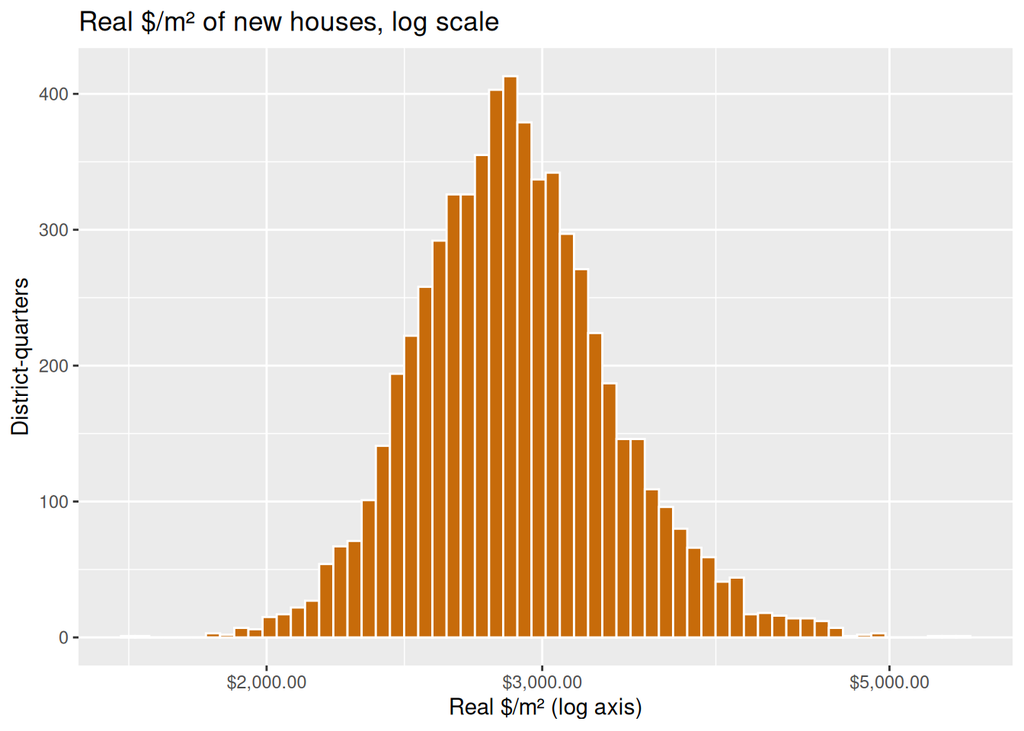

```r
model_frame %>%
  ggplot(aes(x = real_m2)) +
  geom_histogram(bins = 60, fill = "#C76B0A", colour = "white") +
  scale_x_log10(labels = scales::dollar) +
  labs(title = "Real $/m² of new houses, log scale",
       x = "Real $/m² (log axis)", y = "District-quarters")
```

# 7 Saving

```r
saveRDS(model_frame, file.path(derived_dir, "rq1_frame.rds"))
write_csv(model_frame, file.path(derived_dir, "rq1_frame.csv"))
cat("Saved", nrow(model_frame), "rows to", derived_dir, "\n")
```

```
## Saved 6255 rows to /home/harish/Harish/University of Canterbury/Term 1/STAT462-26C4 - Data Mining/Group 8 Project/Dataset/derived
```

The files are written outside the repo, next to the raw data, so no data ends up in the submission.

# 8 Data dictionary

```r
tribble(
  ~column,            ~meaning,
  "area",             "district (territorial authority), as a factor",
  "year, quarter",    "calendar year and calendar quarter",
  "quarter_f",        "calendar quarter as a factor (seasonality)",
  "split",            "train (up to the train end year) or test (after it)",
  "log_real_m2",      "RESPONSE: log of real $/m² of new houses (consented value / floor area, deflated by CEPQ.S61101)",
  "real_m2",          "the same, not logged, in dollars of the latest price index quarter",
  "dollars_per_m2",   "nominal $/m² (kept for reference, not a feature)",
  "houses_n",         "new houses consented in the quarter",
  "multi_unit_share", "1 - houses / dwelling units, new work in the quarter",
  "m2_per_house",     "new floor area per new house",
  "log_houses",       "log of houses_n",
  "nonres_area_share","non-residential share of new floor area",
  "per1000_lag1",     "new dwellings per 1,000 residents, year ending the previous quarter",
  "dw_growth",        "log growth in dwellings, previous four quarters vs the four before them",
  "log_dw_trail4",    "log(1 + dwellings in the previous four quarters)",
  "sa2_top3_share",   "share of the quarter's new dwellings in the district's three busiest SA2s",
  "time_trend",       "year + (quarter - 1) / 4"
) %>% kable()
```

| column | meaning |
| --- | --- |
| area | district (territorial authority), as a factor |
| year, quarter | calendar year and calendar quarter |
| quarter_f | calendar quarter as a factor (seasonality) |
| split | train (up to the train end year) or test (after it) |
| log_real_m2 | RESPONSE: log of real $/m² of new houses (consented value / floor area, deflated by CEPQ.S61101) |
| real_m2 | the same, not logged, in dollars of the latest price index quarter |
| dollars_per_m2 | nominal $/m² (kept for reference, not a feature) |
| houses_n | new houses consented in the quarter |
| multi_unit_share | 1 - houses / dwelling units, new work in the quarter |
| m2_per_house | new floor area per new house |
| log_houses | log of houses_n |
| nonres_area_share | non-residential share of new floor area |
| per1000_lag1 | new dwellings per 1,000 residents, year ending the previous quarter |
| dw_growth | log growth in dwellings, previous four quarters vs the four before them |
| log_dw_trail4 | log(1 + dwellings in the previous four quarters) |
| sa2_top3_share | share of the quarter’s new dwellings in the district’s three busiest SA2s |
| time_trend | year + (quarter - 1) / 4 |

# 9 Decisions made here

1. **One deflator, applied quarter by quarter**, to the latest index quarter’s dollars.
2. **Minimum house count** is set in the settings chunk, with the cost of other choices in the table above.
3. **Features use no dollar values**, and the activity features use only quarters before the one being predicted.
4. **Auckland stays as one territorial authority.** Its scale is handled by the per-1,000 rate and the log house count. The modelling document checks the results with Auckland removed.
5. **Time-ordered split**: train to the end of 2019, test 2020 onwards.
6. **Not done here**: the TA-to-region concordance (no mapping file is in the release), so there is no region feature.

*End of document*